# Project 1: Explore weather trends' solution

*by Cristian Segura Villalobos*

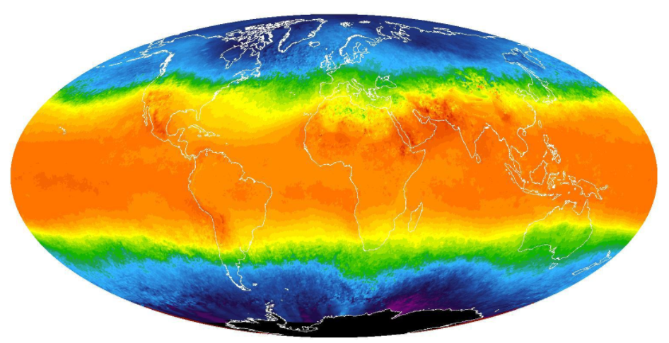

# Table of Content

- Goal
- Data extraction
- Handling csv files
- Moving average graph calculation
- Graphs and analysis
- Final thougths

## Goal

This project's goal is to analyze local and global data and compare temperature trends where I live (Santiago, Chile) to overall global temperature trends.

## Data extraction

### Explore city_list to find my nearest city

##### Finding my city's nearest

To do this, the Udacity' sql workspace was used.

First, the complete list of possible values in city_list table was queried:

```python
SELECT *
  FROM city_list;
```

The result was a list of 342 items with 'city' and 'country' columns

Since there are many cities, a new query was neccesary to compute for the nearest to Santiago, Chile.

```python
SELECT *
  FROM city_list
 WHERE country='Chile';
```

As a result, 2 elements were found: Santiago and Los Angeles

So, my nearest city is **Santiago**

#### Extracting Santiago's weather data

To do this, the following query was executed:

```python
SELECT *
  FROM city_data
 WHERE city='Santiago';
```

As a result, 528 items were found. But there was also information from Santiago in Philipiness and Santiago in Dominican Republic, so, a new and more precisely query was required:

```python
SELECT *
  FROM city_data
 WHERE city='Santiago'
   AND country='Chile';
```

As a result, 159 items were obtained with data from **1855** to **2013**.

#### Validation of the extracted data

A quick validation to check that there is information for each year was executed counting the number of years from 1855 to 2013 and comparing to the number of items as the result for the query. Since there are 159 years between 1855 and 2013 (counting both), we can assume that we at least have data for every year.

A second validation could be check if there are repeated years, but this will be analysed further.

Finally, the data was exported using **"Download CSV"** tool, operation that generated a csv file with the name **"santiago_data.csv"**.

#### Extracting World's global weather data

There is a table named "global_data" that outputs this data, with only 2 columns: 'avg_temp' (global) and 'year'

So, to extract all the information the following query was required:

```python
SELECT *
  FROM global_data;
```

The output was a list of 266 items with year and avg_temp with data from **1750** to **2015**.

So, in this case, **we also have data per every year.**

### Analysys of extraction step

1. We have a quantity mismatch between Santiago and Global data, since we have 159 years with its proper temperature average available for Santiago, Chile. But, we have 266 years of global data. This means that before 1855 and after 2013, the global data does not consider Santiago, Chile information. **For the analysis in this project only data from 1855 to 2013 will be consider**.
2. The query and extraction of the data could be placed in one csv file to ease the analysis, but since there are few registers this will be done in the analysis step directly in an **Excel sheet**.

## Handling CSV files

Both csv files were opened using **Excel**.

The starting point is the following csv:

[figure not shown]

So, spliting this column in multiple columns was needed:

[figure not shown]

This operation was required for both csv files

### Moving average line graph calculation

To calculate the moving average, a time interval definition is required. As a first iteration, a 10 years time frame was selected. For further analysys, other time frames could be selected.

Doing this in Santiago's csv was not possible since the data included decimal values noted with a "." and the moving average was not delivered correctly (a "VALUE!" error appeared).

So to overcome this, the "replace all" tool was used to replace "." per ",".

After doing this, the average for the first ten years was computed, as shown in the following image:

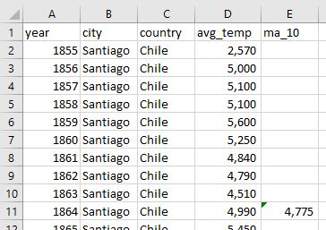

After copying the formula to the rest of the data (shown in the following image), the line graph for Santiago's average and moving average temperature per year could be obtained.

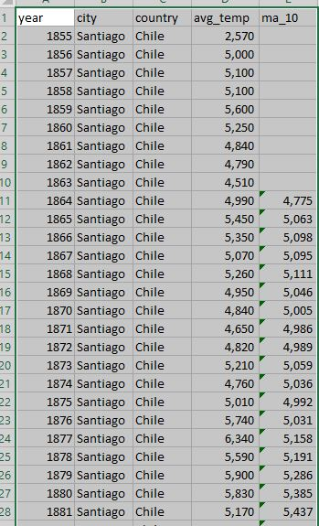

Finally, selecting both year and moving average column and the inserting a line graph, the "Santiago moving average every 10 years, per year" was obtained, as follows.

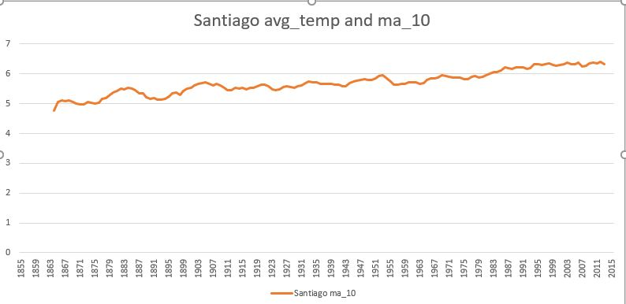

Replying the same method with the world's global temperature data, but considering the same year interval from Santiago information (from 1855 to 2013) the following moving average could be obtained:

[figure not shown]

Finally, the world's global moving average temperature per year was obtained:

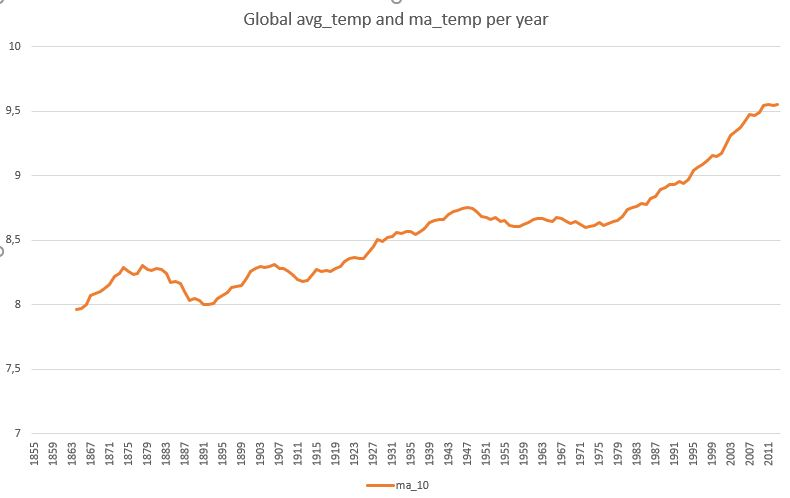

### Graphs and analysis

#### Santiago vs Global data

To ease the comparison analysis, three graphics were added and analysed:

1) **Trend analysys**

A joint line graph showing both, Santiago and global moving average per decade (ma_10) temperature. Showing both curves in one graphic ease the visual comparison trend per year.

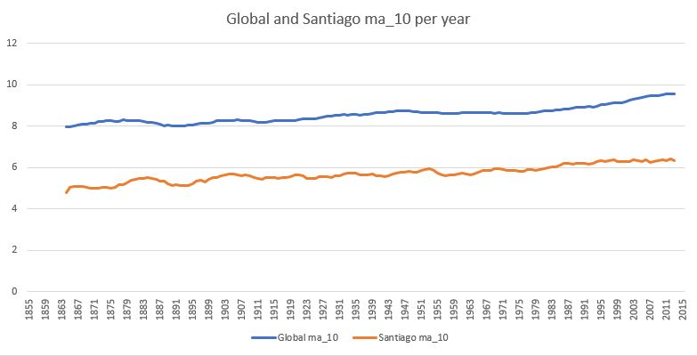

2) Difference in trends analysis:

A new graphic showing the difference between Global and Santiago moving average by decade. This graphic can help us to see what are the years with more and less temperature differences.

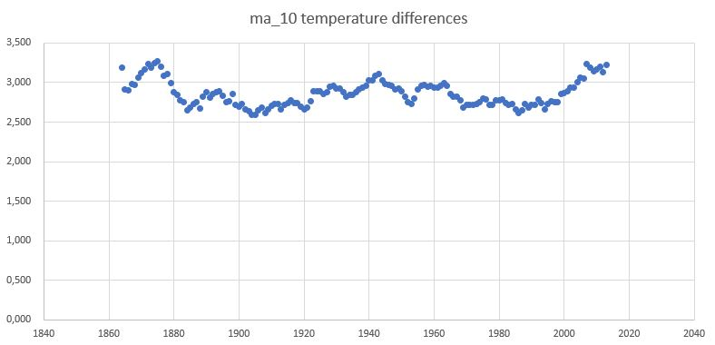

**Analysys**

- We can observe that there is at least a diffence of 2,6° between Santiago and Global temperature (with Santiago been colder).
- We can see that there was a maximum of 3,3° around 1870 and a second maximum of 3,25 around 2010.
- A cycle of temperature difference dropping and increasing of around 10 years can be found between 1870-1880; 1890-1905; 1940-1950;1960-1970. But from 1990 to 2013 the differences have been increasingly higher. This cycles can be explained in part due to the "Niña" and "Niño" phenomenah that ocurs with the sea temperature in the pacific ocean in Chile's coast, which has a significative impact over the rain and temperature in Santiago. The dissapearence of this cycle can be due to the presence of the global warming.

3) Linear regression:

The third graph was computed to see the linear regression curve for Global and Santiago's curves. This was included to try to predict the temperature average from 2014 and further and to compute the correlation coeficient to see how well a linear curve explains the trend.

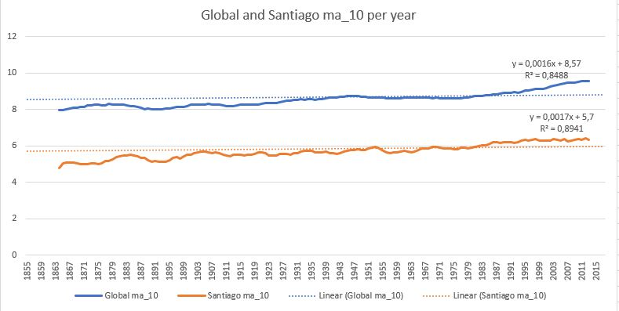

#### Other cities vs Santiago and Global temperature information

The last graph obtained was the result of repeating the procedure with the following cities:

- **Oslo** (baltic, semi continental climate as seen on https://www.climatestotravel.com/climate/norway/oslo )
- **Cairo** (arid and dessert climate as seen on http://www.wordtravels.com/Cities/Egypt/Cairo/Climate )
- **Rio de Janeiro** (tropical climate, as seen on https://www.climatestotravel.com/climate/brazil/rio-de-janeiro)

These cities were selected as a representant of other weather behaviour distinct to Santiago, Chile.

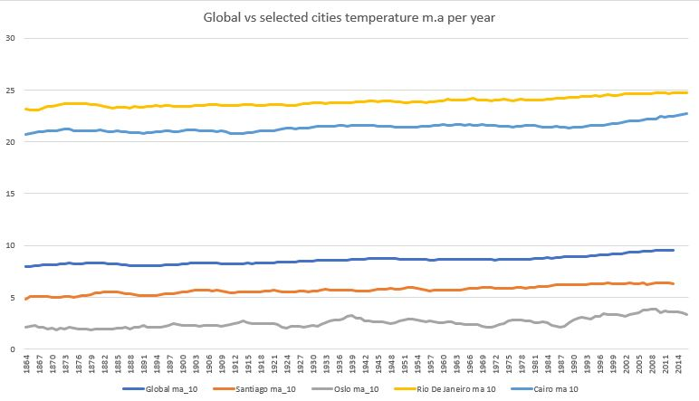

## Final thoughts

- We can observe a rising temperature specially in global data, that can be explained by the global warming phenomenah (the melting of the poles is impacting in the ocean temperatures and the Ozono layer is being compromised due to the greenhouse effect). Our planet is becoming arid!
- By having a yearly average temperature we reduce the season phenomenah that impacts in different ways to north and south earth hemispheres.
- We selected a 10 years moving average for our analysys, but this could be a 20 years time frame to reduce noisy years (specially over 80's decade). Even though, the analysys would be the same.